# Recursos 18

9 actividades, asignación con límite 5→8

# Enunciado

Considere el proyecto cuyo cuadro de prelaciones, duraciones (semanas) y número de operarios necesarios por actividad se adjunta. La empresa sólo dispone de 5 operarios durante las 3 primeras semanas y de 8 a partir de entonces.

1. Dibuje el diagrama de cargas con las actividades en su inicio más temprano y compruebe si se respeta el límite de operarios.

2. Reprograme el proyecto con el algoritmo de asignación de Wiest-Levy para respetar el límite. ¿Qué actividades se desplazan y cuánto se alarga el proyecto?

3. ¿Y si se dispusiera de 5 operarios durante todo el proyecto? Compare las dos duraciones.

4. Explique por qué la asignación puede alargar el proyecto y la nivelación nunca.

Tabla 1: Cuadro de datos del enunciado

| activity | predecessor | duration | resources |
| --- | --- | --- | --- |
| A | --- | 6 | 4 |
| B | --- | 3 | 1 |
| C | A | 2 | 2 |
| D | A,B | 3 | 3 |
| E | B,C | 4 | 2 |
| F | B | 2 | 3 |
| G | F | 2 | 3 |
| H | E,G | 1 | 2 |
| I | D,H | 1 | 2 |

El proyecto corresponde a la instalación de una planta fotovoltaica sobre cubierta; las actividades son las siguientes (las duraciones del cuadro están en semanas).

Tabla 2: Descripción de las actividades

|  | Descripción |
| --- | --- |
| A | Estudio de sombras y producción |
| B | Cálculo estructural de la cubierta |
| C | Tramitación de permisos |
| D | Acopio de módulos e inversores |
| E | Montaje de la estructura soporte |
| F | Colocación de módulos |
| G | Cableado de corriente continua |
| H | Instalación de inversores |
| I | Cuadro de protecciones y contador |

# Resolución

## Apartado 1

1. Dibuje el diagrama de cargas con las actividades en su inicio más temprano y compruebe si se respeta el límite de operarios.

Cálculo de los tiempos tempranos y tardíos de los sucesos y de las holguras totales paso a paso. El primer paso muestra el grafo resuelto; a partir del siguiente se calcula desde el principio (avance con los botones):

[figure not shown]

paso 0 de 32

[figure not shown]

Figura 1: Grafo PERT con tiempos y camino crítico

Tabla 3: Calendario: fechas y holgura total de cada actividad

[figure not shown]

ninguna celda (0 de 72)

[figure not shown]

Haz clic en un número de la tabla para ver cómo se calcula.

👆 **Interactivo:** haz clic en cualquier celda de la tabla para ver cómo se calcula (otro clic la deselecciona), o usa los botones y las flechas del teclado.

| Actividad | Duración | Inicio más temprano | Fin más temprano | Inicio más tardío | Fin más tardío | H total | H libre | H independiente |
| --- | --- | --- | --- | --- | --- | --- | --- | --- |
| A | 6 | 0 | 6 | 0 | 6 | 0 | 0 | 0 |
| B | 3 | 0 | 3 | 5 | 8 | 5 | 0 | 0 |
| C | 2 | 6 | 8 | 6 | 8 | 0 | 0 | 0 |
| D | 3 | 6 | 9 | 10 | 13 | 4 | 4 | 2 |
| E | 4 | 8 | 12 | 8 | 12 | 0 | 0 | 0 |
| F | 2 | 3 | 5 | 8 | 10 | 5 | 0 | 0 |
| G | 2 | 5 | 7 | 10 | 12 | 5 | 5 | 0 |
| H | 1 | 12 | 13 | 12 | 13 | 0 | 0 | 0 |
| I | 1 | 13 | 14 | 13 | 14 | 0 | 0 | 0 |

En el Gantt cada actividad empieza en su inicio más temprano y la casilla lleva los operarios que ocupa; la fila *Total* suma la columna (carga de la semana) y la fila *Cuadrados* eleva cada carga al cuadrado (su suma, en la última columna, es la medida de desnivel que usa la nivelación).

[figure not shown]

Figura 2: Diagrama de Gantt con las cargas de operarios (inicios más tempranos)

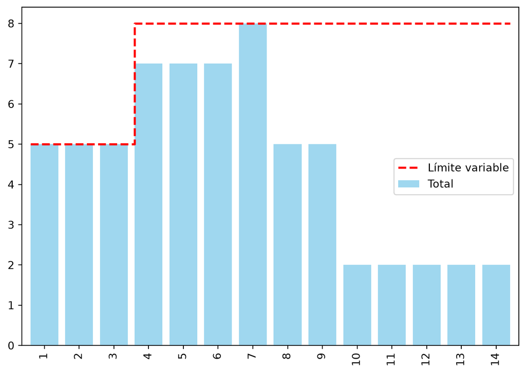

Figura 3: Diagrama de cargas con el límite de operarios

**Respuesta:** sí se respeta: la carga no supera el límite en ninguna semana. El pico, 8 operarios en la semana 7, cae ya en el tramo con límite 8, y en las semanas con límite 5 la carga no pasa de 5.

## Apartado 2

2. Reprograme el proyecto con el algoritmo de asignación de Wiest-Levy para respetar el límite. ¿Qué actividades se desplazan y cuánto se alarga el proyecto?

El algoritmo de asignación (Wiest-Levy en la librería) recorre el calendario semana a semana y aplaza lo que no cabe; si no basta con consumir holguras, aplaza también actividades críticas y el proyecto se alarga. Las filas 💤 del Gantt marcan las esperas introducidas.

Regla del algoritmo: en cada semana se toman las actividades que el calendario vigente sitúa en ella y se ordenan así: primero las ya empezadas (no se interrumpen); después, menor holgura total (recalculada tras los aplazamientos anteriores) y, a igualdad, menor duración. Se admiten en ese orden mientras la suma de recursos no supere el límite; las que no caben se aplazan una semana (y con ellas sus sucesoras, si no tienen holgura). En la traza, *Total* es la demanda de esa semana antes de aplazar.

Traza semana a semana (qué se programa y qué se aplaza una semana):

Periodo: 1.

Periodo: 1. Total: 5. Se programan: [‘A’, ‘B’]

Periodo: 2.

Periodo: 2. Total: 5. Se programan: [‘A’, ‘B’]

Periodo: 3.

Periodo: 3. Total: 5. Se programan: [‘A’, ‘B’]

Periodo: 4.

Periodo: 4. Total: 7. Se programan: [‘A’, ‘F’]

Periodo: 5.

Periodo: 5. Total: 7. Se programan: [‘A’, ‘F’]

Periodo: 6.

Periodo: 6. Total: 7. Se programan: [‘A’, ‘G’]

Periodo: 7.

Periodo: 7. Total: 8. Se programan: [‘G’, ‘D’, ‘C’]

Periodo: 8.

Periodo: 8. Total: 5. Se programan: [‘D’, ‘C’]

Periodo: 9.

Periodo: 9. Total: 5. Se programan: [‘D’, ‘E’]

Periodo: 10.

Periodo: 10. Total: 2. Se programan: [‘E’]

Periodo: 11.

Periodo: 11. Total: 2. Se programan: [‘E’]

Periodo: 12.

Periodo: 12. Total: 2. Se programan: [‘E’]

Periodo: 13.

Periodo: 13. Total: 2. Se programan: [‘H’]

Periodo: 14.

Periodo: 14. Total: 2. Se programan: [‘I’]

Por qué se aplaza cada actividad: en las semanas en que la demanda supera el límite, la tabla da el orden de prioridad (con su holgura, duración y operarios), las que entran y, para cada aplazada, la suma que no cabe.

Tabla 4: Semanas con conflicto en la asignación

En ninguna semana la demanda supera el límite: no hay que aplazar nada.

[figure not shown]

Figura 4: Diagrama de Gantt tras la asignación

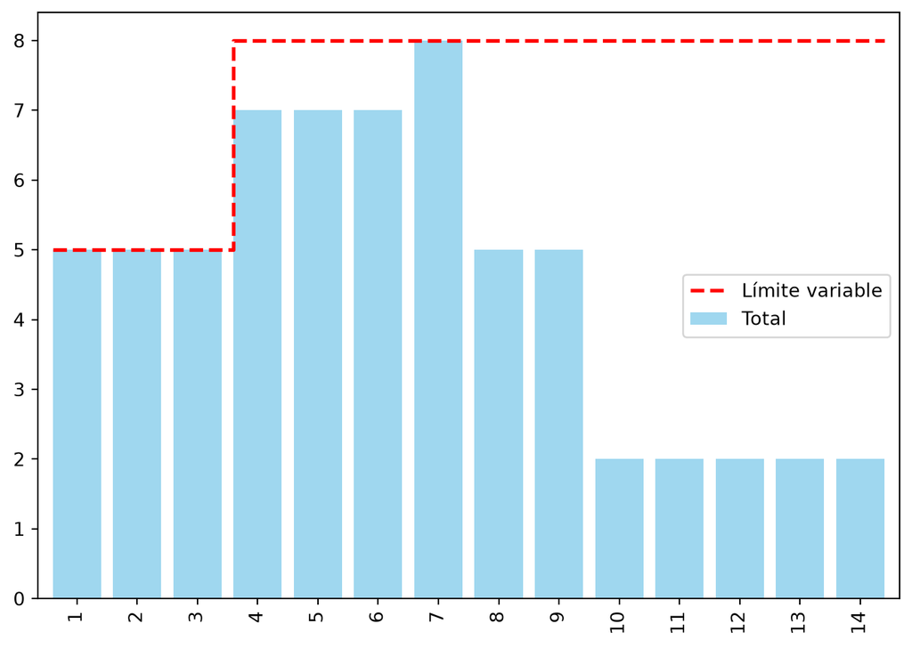

Figura 5: Diagrama de cargas tras la asignación

**Respuesta:** no hace falta desplazar ninguna actividad: el proyecto mantiene sus 14 semanas.

## Apartado 3

3. ¿Y si se dispusiera de 5 operarios durante todo el proyecto? Compare las dos duraciones.

Periodo: 1.

Periodo: 1. Total: 5. Se programan: [‘A’, ‘B’]

Periodo: 2.

Periodo: 2. Total: 5. Se programan: [‘A’, ‘B’]

Periodo: 3.

Periodo: 3. Total: 5. Se programan: [‘A’, ‘B’]

Periodo: 4.

Periodo: 4. Total: 7. Se programan: [‘A’]

Periodo: 4. Se desplazan: [‘F’]

Periodo: 5.

Periodo: 5. Total: 7. Se programan: [‘A’]

Periodo: 5. Se desplazan: [‘F’]

Periodo: 6.

Periodo: 6. Total: 7. Se programan: [‘A’]

Periodo: 6. Se desplazan: [‘F’]

Periodo: 7.

Periodo: 7. Total: 8. Se programan: [‘C’, ‘F’]

Periodo: 7. Se desplazan: [‘D’]

Periodo: 8.

Periodo: 8. Total: 8. Se programan: [‘C’, ‘F’]

Periodo: 8. Se desplazan: [‘D’]

Periodo: 9.

Periodo: 9. Total: 8. Se programan: [‘G’, ‘E’]

Periodo: 9. Se desplazan: [‘D’]

Periodo: 10.

Periodo: 10. Total: 8. Se programan: [‘G’, ‘E’]

Periodo: 10. Se desplazan: [‘D’]

Periodo: 11.

Periodo: 11. Total: 5. Se programan: [‘D’, ‘E’]

Periodo: 12.

Periodo: 12. Total: 5. Se programan: [‘D’, ‘E’]

Periodo: 13.

Periodo: 13. Total: 5. Se programan: [‘D’, ‘H’]

Periodo: 14.

Periodo: 14. Total: 2. Se programan: [‘I’]

Tabla 5: Semanas con conflicto con el límite constante

| semana | límite | demanda | orden de prioridad (holgura, duración, recurso) | entran | se aplazan una semana (no caben) |
| --- | --- | --- | --- | --- | --- |
| 4 | 5 | 7 | A (en curso, 4) › F (H=5, d=2, 3) | A | F: 4 + 3 = 7 > 5 |
| 5 | 5 | 7 | A (en curso, 4) › F (H=4, d=2, 3) | A | F: 4 + 3 = 7 > 5 |
| 6 | 5 | 7 | A (en curso, 4) › F (H=3, d=2, 3) | A | F: 4 + 3 = 7 > 5 |
| 7 | 5 | 8 | C (H=0, d=2, 2) › F (H=2, d=2, 3) › D (H=4, d=3, 3) | C y F | D: 5 + 3 = 8 > 5 |
| 8 | 5 | 8 | C (en curso, 2) › F (en curso, 3) › D (H=3, d=3, 3) | C y F | D: 5 + 3 = 8 > 5 |
| 9 | 5 | 8 | E (H=0, d=4, 2) › G (H=2, d=2, 3) › D (H=2, d=3, 3) | E y G | D: 5 + 3 = 8 > 5 |
| 10 | 5 | 8 | E (en curso, 2) › G (en curso, 3) › D (H=1, d=3, 3) | E y G | D: 5 + 3 = 8 > 5 |

[figure not shown]

Figura 6: Diagrama de Gantt con el límite constante

Esperas con el límite constante: F 3 semanas y D 4 semanas.

**Respuesta:** con 5 operarios durante todo el proyecto la duración sería de 14 semanas, frente a 14 con el refuerzo a 8 operarios a partir de la semana 4; la misma duración; en este proyecto el refuerzo no acorta el plazo.

## Apartado 4

4. Explique por qué la asignación puede alargar el proyecto y la nivelación nunca.

La nivelación sólo usa las holguras: desplaza actividades no críticas sin tocar el plazo, y si un desplazamiento alargara el proyecto no se prueba. La asignación impone una restricción dura (el límite de cada semana); si ni siquiera aplazando todas las actividades con holgura cabe la demanda, tiene que aplazar actividades críticas y el proyecto se alarga. **Respuesta:** aquí, con los límites del enunciado, no ha hecho falta aplazar nada; la nivelación, por construcción, nunca cambia la duración.